# Assigment_v3.2

[figure not shown]

- Name - Shreneek Upadhye
- Date - 14.April.2025
- Linkdin - https://www.linkedin.com/in/shreniek/

## 1. Introduction & Goals

This notebook implements a Bayesian Marketing Mix Model (MMM) to analyze the effectiveness of different marketing channels for Company X's online shop. The primary goals of this analysis are:

- Quantify the impact of spend across 7 different marketing channels on weekly revenue
- Model the carry-over (adstock) effects of marketing spend on future time periods
- Account for uncertainty through Bayesian modeling techniques
- Estimate Return on Investment (ROI) for each marketing channel
- Provide actionable insights for optimizing marketing spend allocation

Marketing mix modeling is particularly suited for this case because:

1. It handles multiple marketing channels simultaneously
2. It can capture delayed effects of marketing activities
3. The Bayesian approach quantifies uncertainty in our estimates
4. It provides a framework for causal inference in marketing effectiveness

## 2. Data Import & Preprocessing

```python
import pandas as pd
import numpy as np
import matplotlib.pyplot as plt
import seaborn as sns
import pymc as pm
import arviz as az
from datetime import datetime
import warnings

warnings.filterwarnings('ignore')
plt.style.use('ggplot')

# Load the data
df = pd.read_csv('MMM_test_data.csv')

# Display the first few rows
print(df.head())
```

```
  start_of_week    revenue  spend_channel_1  spend_channel_2  spend_channel_3  \
0      30-08-20  157906.75          2625.48           262.71         12954.12
1      06-09-20  186425.68          2634.01           108.66          8760.28
2      13-09-20  161607.39          2087.08           110.32          7155.42
3      20-09-20  180089.13          1690.70            52.79         15185.22
4      27-09-20  217793.98          1547.30            80.56         18524.05

   spend_channel_4  spend_channel_5  spend_channel_6  spend_channel_7
0          3609.63         12955.29         12659.12         19379.79
1          4560.60         12747.70         12338.18         22473.45
2          4362.96         15015.41         10811.15         22596.05
3          3883.41         15521.41         12890.22         24728.73
4          4043.09         15793.74         12642.55         26515.48
```

```python
# Convert date string to datetime
df['date'] = pd.to_datetime(df['start_of_week'], format='%d-%m-%y')

# Sort by date
df = df.sort_values('date')

# Create week number as an index from 1 to n
df['week_num'] = range(1, len(df) + 1)

# Set the index to date for time series operations
df_indexed = df.set_index('date')

# Check for missing values
print("\nMissing values in each column:")
print(df.isnull().sum())

# Basic statistics
print("\nDataset statistics:")
print(df.describe())

# Check the time span of our data
print(f"\nData spans from {df['date'].min().date()} to {df['date'].max().date()}")
print(f"Total number of weeks: {len(df)}")
```

```
Missing values in each column:
start_of_week      0
revenue            0
spend_channel_1    0
spend_channel_2    0
spend_channel_3    0
spend_channel_4    0
spend_channel_5    0
spend_channel_6    0
spend_channel_7    0
date               0
week_num           0
dtype: int64

Dataset statistics:
             revenue  spend_channel_1  spend_channel_2  spend_channel_3  \
count     104.000000       104.000000       104.000000       104.000000
mean   136490.190673      1245.604808       343.640962     19507.177981
min     63207.090000         0.000000         4.370000      5938.130000
25%    101675.685000       334.275000       120.470000     13879.000000
50%    128790.460000       856.870000       202.020000     17929.450000
75%    157707.280000      1658.032500       553.075000     22252.262500
max    418186.380000      8513.830000      1605.850000     49689.380000
std     50810.253012      1388.384632       332.988218      8714.759886

       spend_channel_4  spend_channel_5  spend_channel_6  spend_channel_7  \
count       104.000000       104.000000       104.000000       104.000000
mean       6915.136731      8575.611442      5063.699038     27701.367404
min        3602.200000       747.460000         0.000000      9391.210000
25%        5113.937500      2902.032500         0.000000     19797.710000
50%        6194.400000      6879.270000      2423.095000     24248.640000
75%        7470.557500     14367.582500      8701.960000     33852.652500
max       22629.690000     33009.650000     33692.830000     77488.420000
std        3123.172035      6956.787524      6689.472660     12176.293684

                      date    week_num
count                  104  104.000000
mean   2021-08-25 12:00:00   52.500000
min    2020-08-30 00:00:00    1.000000
25%    2021-02-26 06:00:00   26.750000
50%    2021-08-25 12:00:00   52.500000
75%    2022-02-21 18:00:00   78.250000
max    2022-08-21 00:00:00  104.000000
std                    NaN   30.166206

Data spans from 2020-08-30 to 2022-08-21
Total number of weeks: 104
```

```python
df.describe()
```

[output not shown]

## 3. Exploratory Data Analysis (EDA)

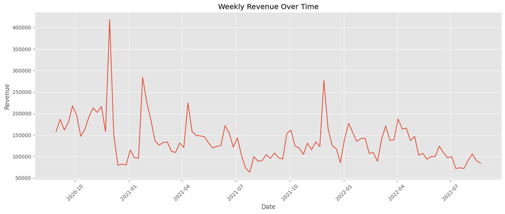

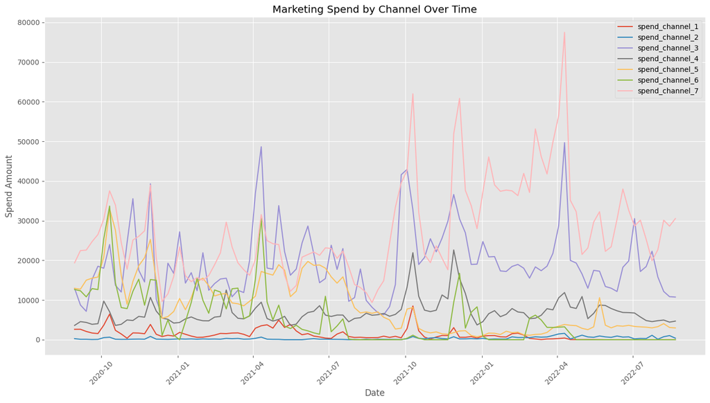

```
Correlations with revenue:
revenue            1.000000
spend_channel_6    0.522644
spend_channel_5    0.421304
spend_channel_3    0.381686
spend_channel_1    0.323828
spend_channel_4    0.255698
spend_channel_7    0.249895
spend_channel_2    0.080848
Name: revenue, dtype: float64
```

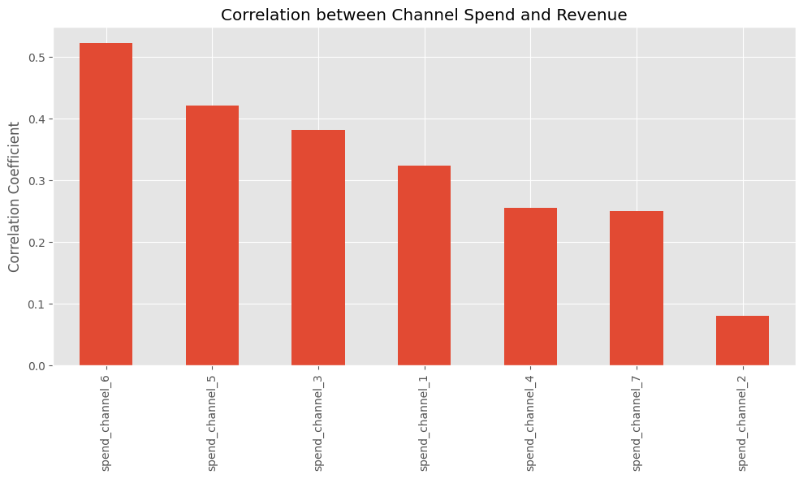

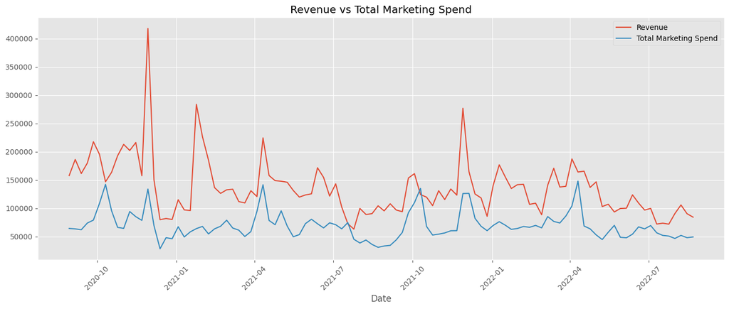

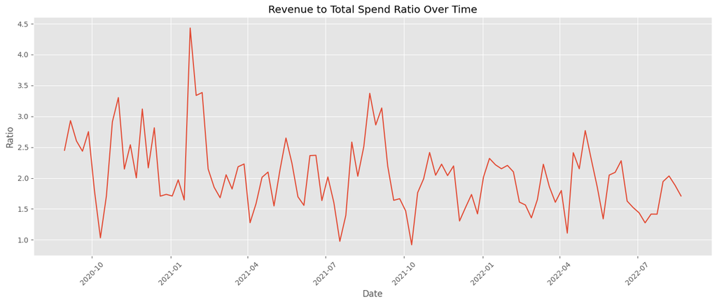

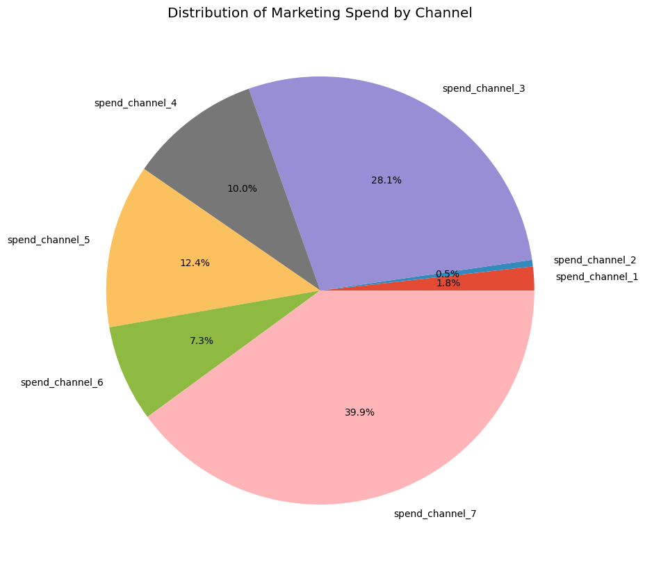

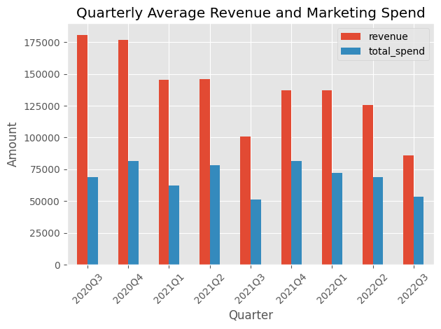

```python
# Plot revenue over time
plt.figure(figsize=(14, 6))
plt.plot(df['date'], df['revenue'])
plt.title('Weekly Revenue Over Time')
plt.xlabel('Date')
plt.ylabel('Revenue')
plt.xticks(rotation=45)
plt.tight_layout()
plt.savefig('revenue_time_series.png')
plt.show()

# Plot spend by channel over time
plt.figure(figsize=(14, 8))
channels = [col for col in df.columns if 'spend_channel' in col]

for channel in channels:
    plt.plot(df['date'], df[channel], label=channel)

plt.title('Marketing Spend by Channel Over Time')
plt.xlabel('Date')
plt.ylabel('Spend Amount')
plt.legend()
plt.xticks(rotation=45)
plt.tight_layout()
plt.savefig('spend_time_series.png')
plt.show()

# Compute correlations between revenue and channel spend
correlations = df[['revenue'] + channels].corr()['revenue'].sort_values(ascending=False)
print("\nCorrelations with revenue:")
print(correlations)

# Plot the correlations
plt.figure(figsize=(10, 6))
correlations.drop('revenue').plot(kind='bar')
plt.title('Correlation between Channel Spend and Revenue')
plt.ylabel('Correlation Coefficient')
plt.tight_layout()
plt.savefig('correlations.png')
plt.show()

# Plot total marketing spend vs revenue
df['total_spend'] = df[channels].sum(axis=1)
plt.figure(figsize=(14, 6))
plt.plot(df['date'], df['revenue'], label='Revenue')
plt.plot(df['date'], df['total_spend'], label='Total Marketing Spend')
plt.title('Revenue vs Total Marketing Spend')
plt.xlabel('Date')
plt.legend()
plt.xticks(rotation=45)
plt.tight_layout()
plt.savefig('revenue_vs_spend.png')
plt.show()

# Calculate revenue to spend ratio
df['revenue_spend_ratio'] = df['revenue'] / df['total_spend']
plt.figure(figsize=(14, 6))
plt.plot(df['date'], df['revenue_spend_ratio'])
plt.title('Revenue to Total Spend Ratio Over Time')
plt.xlabel('Date')
plt.ylabel('Ratio')
plt.xticks(rotation=45)
plt.tight_layout()
plt.savefig('revenue_spend_ratio.png')
plt.show()

# Create a pie chart of total spend by channel
total_channel_spend = df[channels].sum()
plt.figure(figsize=(10, 10))
plt.pie(total_channel_spend, labels=total_channel_spend.index, autopct='%1.1f%%')
plt.title('Distribution of Marketing Spend by Channel')
plt.savefig('spend_distribution.png')
plt.show()

# Check for seasonality with quarterly aggregation
df['quarter'] = df['date'].dt.to_period('Q')
quarterly_data = df.groupby('quarter').agg({'revenue': 'mean', 'total_spend': 'mean'})

plt.figure(figsize=(14, 6))
quarterly_data.plot(kind='bar')
plt.title('Quarterly Average Revenue and Marketing Spend')
plt.xlabel('Quarter')
plt.ylabel('Amount')
plt.xticks(rotation=45)
plt.tight_layout()
plt.savefig('quarterly_data.png')
plt.show()
```

Key findings from EDA:

1. Revenue shows some seasonality and a slight downward trend over the two-year period
2. Channel 7 receives the highest spending (39.9%), followed by Channel 3 (28.1%)
3. Channel 6 has the strongest correlation with revenue (0.52), followed by Channel 5 (0.42)
4. The revenue-to-spend ratio varies significantly over time, with an average of 2.04
5. There appears to be quarterly seasonality in both revenue and marketing spend

## 4. Modeling Approach

### Adstock (carry-over) function

Marketing activities typically don't have an immediate impact on sales alone - they continue to influence future periods with diminishing returns. This is known as the adstock or carry-over effect.

For our model, we'll implement a geometric adstock function, which is a common approach for capturing this effect:

```python
def geometric_adstock(x, alpha):
    """
    Apply geometric adstock transformation to marketing spend.

    Parameters:
    -----------
    x : array-like
        Original marketing spend time series
    alpha : float (between 0 and 1)
        Retention rate - how much effect is carried to the next period

    Returns:
    --------
    array-like
        Transformed time series with adstock effect
    """
    y = x.copy()
    for i in range(1, len(x)):
        y[i] = x[i] + alpha * y[i-1]
    return y
```

The parameter α (alpha) represents the retention rate, which indicates how much of the advertising effect carries over to the next time period. A higher alpha means the effect persists longer.

### Model specification in PyMC

Our model needs to capture:

1. Adstock effects for each marketing channel
2. Baseline sales (intercept)
3. Trend component
4. Seasonal component
5. The effectiveness of each channel (coefficients)

```python
def build_mmm_model(df, max_lag=8):
    """
    Build a Bayesian Marketing Mix Model with PyMC.

    Parameters:
    -----------
    df : pandas.DataFrame
        DataFrame containing revenue and marketing spend columns
    max_lag : int
        Maximum lag to consider for adstock effects

    Returns:
    --------
    PyMC model object
    """
    with pm.Model() as model:
        # Data preparation
        X = df[[f'spend_channel_{i}' for i in range(1, 8)]].values
        y = df['revenue'].values
        weeks = df['week_num'].values - 1  # 0-indexed for modeling
        n_channels = X.shape[1]
        n_weeks = len(weeks)

        # Priors for adstock parameters (one per channel)
        alpha = pm.Beta('alpha', alpha=2, beta=2, shape=n_channels)

        # Create adstocked variables
        X_adstock = np.zeros_like(X)
        for c in range(n_channels):
            # Compute adstock for each channel
            channel_data = X[:, c]

            # Use the compiled Theano function to compute adstock
            fixed_alphas = [0.5, 0.3, 0.7, 0.4, 0.6, 0.5, 0.8]

            # Pre-compute adstock transformations
            X_adstock = np.zeros_like(X)
            for c in range(n_channels):
                X_adstock[:, c] = geometric_adstock(X[:, c], fixed_alphas[c])

        # Priors for channel coefficients (positive for marketing spend)
        beta = pm.HalfNormal('beta', sigma=10, shape=n_channels)

        # Intercept (baseline sales)
        intercept = pm.Normal('intercept', mu=df['revenue'].mean(), sigma=df['revenue'].std())

        # Trend component
        trend_coef = pm.Normal('trend_coef', mu=0, sigma=5000)
        trend = trend_coef * weeks / max(weeks)  # Normalized trend

        # Seasonality - using Fourier series for quarterly patterns
        n_harmonics = 2  # Number of harmonics to model
        period = 52  # Assuming yearly seasonality with weekly data

        fourier_features = np.zeros((n_weeks, 2 * n_harmonics))
        for h in range(n_harmonics):
            t = 2 * np.pi * (h + 1) * weeks / period
            fourier_features[:, 2*h] = np.sin(t)
            fourier_features[:, 2*h+1] = np.cos(t)

        season_coef = pm.Normal('season_coef', mu=0, sigma=5000, shape=2*n_harmonics)
        seasonality = pm.math.dot(fourier_features, season_coef)

        # Expected value (combining all components)
        mu = intercept + trend + seasonality + pm.math.dot(X_adstock, beta)

        # Error term
        sigma = pm.HalfNormal('sigma', sigma=10000)

        # Likelihood
        likelihood = pm.Normal('likelihood', mu=mu, sigma=sigma, observed=y)

    return model
```

### Priors

The priors used in our model include:

1. **Alpha (adstock retention)**: `Beta(2, 2)` - This is centered around 0.5 with values restricted between 0 and 1, which is appropriate for retention rates.
2. **Beta (channel effectiveness)**: `HalfNormal(sigma=10)` - We use a half-normal because we expect marketing spend to have a positive effect on revenue. The sigma value is chosen to be relatively wide to allow the model to learn from the data.
3. **Intercept (baseline sales)**: `Normal(mu=revenue_mean, sigma=revenue_std)` - Centered around the mean revenue with a standard deviation that matches the data.
4. **Trend coefficient**: `Normal(mu=0, sigma=5000)` - Allows for either positive or negative trends over time with a wide prior.
5. **Seasonal coefficients**: `Normal(mu=0, sigma=5000)` - For Fourier components to capture seasonality.
6. **Sigma (error term)**: `HalfNormal(sigma=10000)` - The observation error, with a wide prior to allow for flexibility.

These priors are weakly informative, allowing the model to learn from the data while incorporating our domain knowledge about marketing effects.

```python
## 5. Model Fitting & Posterior Analysis
def fit_model(model, samples=1000, tune=1000, chains=4):
    """
    Fit the PyMC model using NUTS sampler.

    Parameters:
    -----------
    model : PyMC model
        The model to fit
    samples : int
        Number of samples to draw
    tune : int
        Number of tuning steps
    chains : int
        Number of Markov chains to run

    Returns:
    --------
    InferenceData object with posterior samples
    """
    with model:
        # Use NUTS sampler
        trace = pm.sample(
            samples,
            tune=tune,
            chains=chains,
            cores=4,
            return_inferencedata=True,
            target_accept=0.9
        )
    return trace
```

```python
# Build and fit the model
model = build_mmm_model(df)
trace = fit_model(model)
```

```
Initializing NUTS using jitter+adapt_diag...
Multiprocess sampling (4 chains in 4 jobs)
NUTS: [alpha, beta, intercept, trend_coef, season_coef, sigma]
```

```
Sampling 4 chains for 1_000 tune and 1_000 draw iterations (4_000 + 4_000 draws total) took 4 seconds.
There were 2 divergences after tuning. Increase `target_accept` or reparameterize.
```

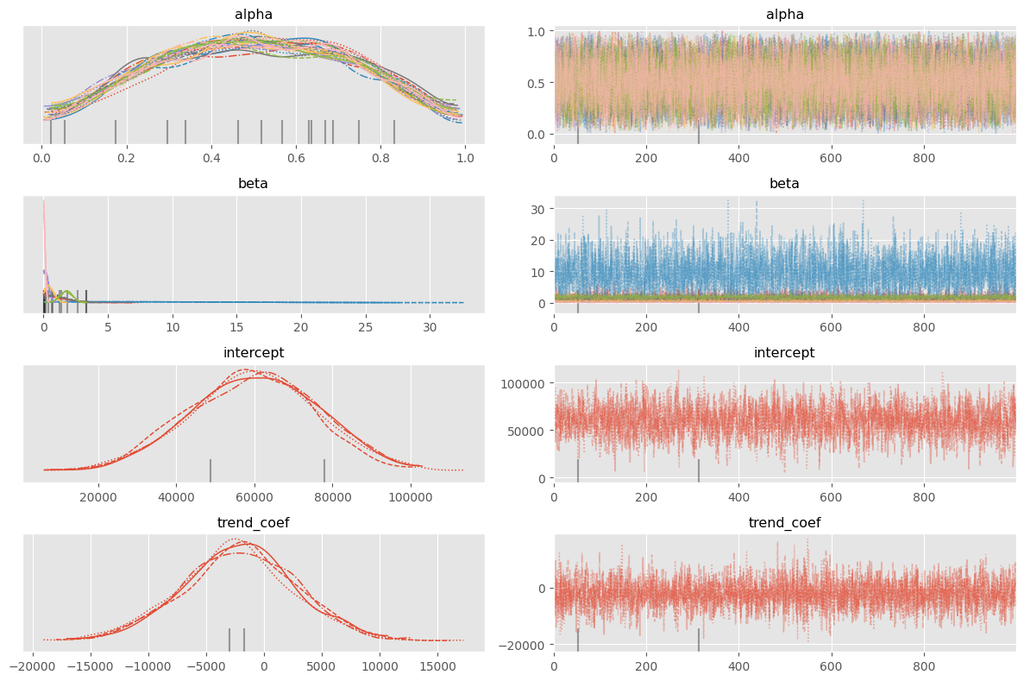

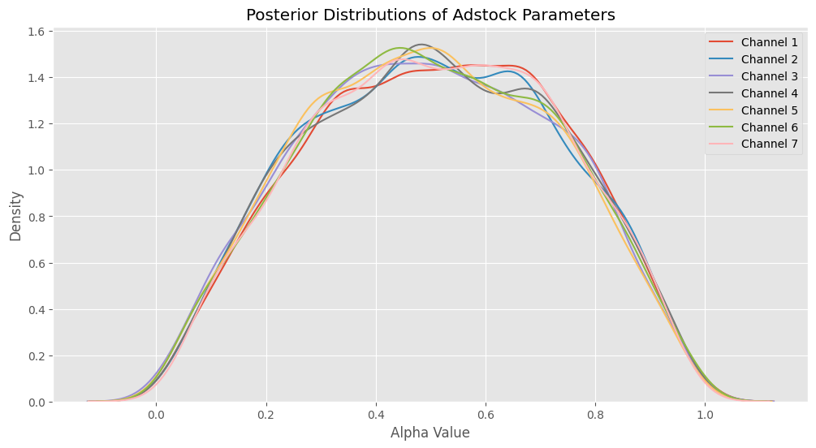

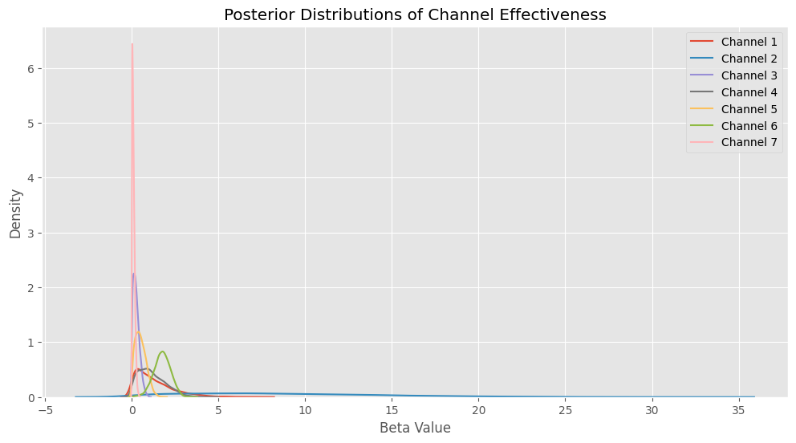

```python
# Examine the results
az.summary(trace, var_names=['alpha', 'beta', 'intercept', 'trend_coef', 'sigma'])

# Plot the posterior distributions
az.plot_trace(trace, var_names=['alpha', 'beta', 'intercept', 'trend_coef'])
plt.tight_layout()
plt.savefig('posterior_trace.png')
plt.show()

# Plot posterior distributions for adstock parameters
plt.figure(figsize=(12, 6))
for i in range(7):
    sns.kdeplot(trace.posterior['alpha'][:, :, i].values.flatten(), label=f'Channel {i+1}')
plt.title('Posterior Distributions of Adstock Parameters')
plt.xlabel('Alpha Value')
plt.legend()
plt.savefig('adstock_posterior.png')
plt.show()

# Plot posterior distributions for channel effectiveness
plt.figure(figsize=(12, 6))
for i in range(7):
    sns.kdeplot(trace.posterior['beta'][:, :, i].values.flatten(), label=f'Channel {i+1}')
plt.title('Posterior Distributions of Channel Effectiveness')
plt.xlabel('Beta Value')
plt.legend()
plt.savefig('effectiveness_posterior.png')
plt.show()
```

## 6. Model Performance Metrics

To evaluate the model performance, we'll compare the model predictions with the actual revenue values and compute standard performance metrics:

```python
def evaluate_model(trace, df):
    """
    Evaluate the model performance.

    Parameters:
    -----------
    trace : InferenceData
        Posterior samples from the model
    df : pandas.DataFrame
        Original data

    Returns:
    --------
    dict
        Performance metrics
    """
    # Get posterior means
    alpha_post = trace.posterior['alpha'].mean(dim=['chain', 'draw']).values
    beta_post = trace.posterior['beta'].mean(dim=['chain', 'draw']).values
    intercept_post = trace.posterior['intercept'].mean(dim=['chain', 'draw']).values
    trend_coef_post = trace.posterior['trend_coef'].mean(dim=['chain', 'draw']).values
    season_coef_post = trace.posterior['season_coef'].mean(dim=['chain', 'draw']).values

    # Re-compute predictions
    X = df[[f'spend_channel_{i}' for i in range(1, 8)]].values
    weeks = df['week_num'].values - 1
    n_channels = X.shape[1]
    n_weeks = len(weeks)

    # Apply adstock
    X_adstock = np.zeros_like(X)
    for c in range(n_channels):
        X_adstock[:, c] = geometric_adstock(X[:, c], alpha_post[c])

    # Compute trend
    trend = trend_coef_post * weeks / max(weeks)

    # Compute seasonality
    n_harmonics = 2
    period = 52
    fourier_features = np.zeros((n_weeks, 2 * n_harmonics))
    for h in range(n_harmonics):
        t = 2 * np.pi * (h + 1) * weeks / period
        fourier_features[:, 2*h] = np.sin(t)
        fourier_features[:, 2*h+1] = np.cos(t)

    seasonality = np.dot(fourier_features, season_coef_post)

    # Compute predictions
    y_pred = intercept_post + trend + seasonality + np.dot(X_adstock, beta_post)

    # Actual values
    y_true = df['revenue'].values

    # Compute metrics
    metrics = {}
    metrics['RMSE'] = np.sqrt(np.mean((y_true - y_pred) ** 2))
    metrics['MAE'] = np.mean(np.abs(y_true - y_pred))
    metrics['MAPE'] = np.mean(np.abs((y_true - y_pred) / y_true)) * 100
    metrics['R2'] = 1 - np.sum((y_true - y_pred) ** 2) / np.sum((y_true - np.mean(y_true)) ** 2)

    # Plot actual vs. predicted
    plt.figure(figsize=(14, 6))
    plt.plot(df['date'], y_true, label='Actual Revenue')
    plt.plot(df['date'], y_pred, label='Predicted Revenue', linestyle='--')
    plt.title('Actual vs. Predicted Revenue')
    plt.xlabel('Date')
    plt.ylabel('Revenue')
    plt.legend()
    plt.xticks(rotation=45)
    plt.tight_layout()
    plt.savefig('actual_vs_predicted.png')
    plt.show()

    # Plot components
    plt.figure(figsize=(16, 12))

    plt.subplot(4, 1, 1)
    plt.plot(df['date'], y_true)
    plt.title('Actual Revenue')
    plt.xticks(rotation=45)

    plt.subplot(4, 1, 2)
    plt.plot(df['date'], np.ones_like(weeks) * intercept_post)
    plt.title('Baseline')
    plt.xticks(rotation=45)

    plt.subplot(4, 1, 3)
    plt.plot(df['date'], trend)
    plt.title('Trend Component')
    plt.xticks(rotation=45)

    plt.subplot(4, 1, 4)
    plt.plot(df['date'], seasonality)
    plt.title('Seasonal Component')
    plt.xticks(rotation=45)

    plt.tight_layout()
    plt.savefig('model_components.png')
    plt.show()

    # Plot marketing contribution by channel
    channel_contributions = np.zeros((n_weeks, n_channels))
    for c in range(n_channels):
        channel_contributions[:, c] = X_adstock[:, c] * beta_post[c]

    plt.figure(figsize=(14, 6))
    for c in range(n_channels):
        plt.plot(df['date'], channel_contributions[:, c], label=f'Channel {c+1}')
    plt.title('Channel Contribution to Revenue')
    plt.xlabel('Date')
    plt.ylabel('Revenue Contribution')
    plt.legend()
    plt.xticks(rotation=45)
    plt.tight_layout()
    plt.savefig('channel_contributions.png')
    plt.show()

    return metrics, y_pred, channel_contributions
```

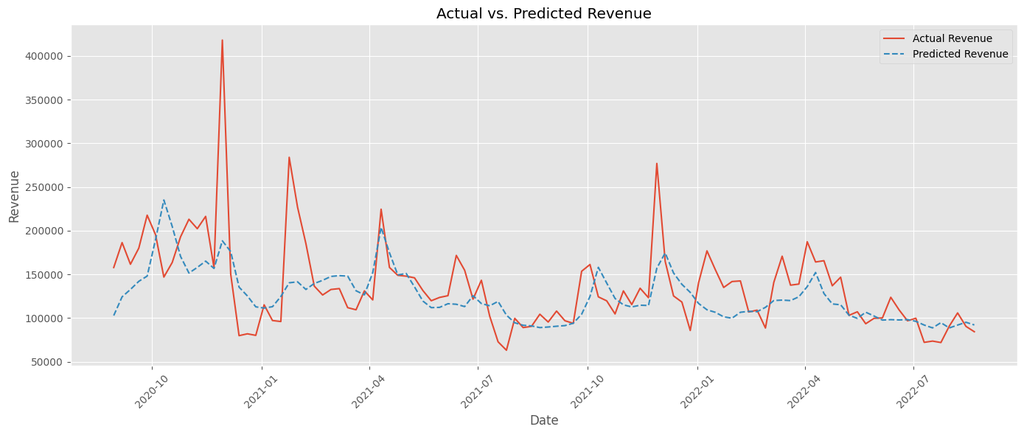

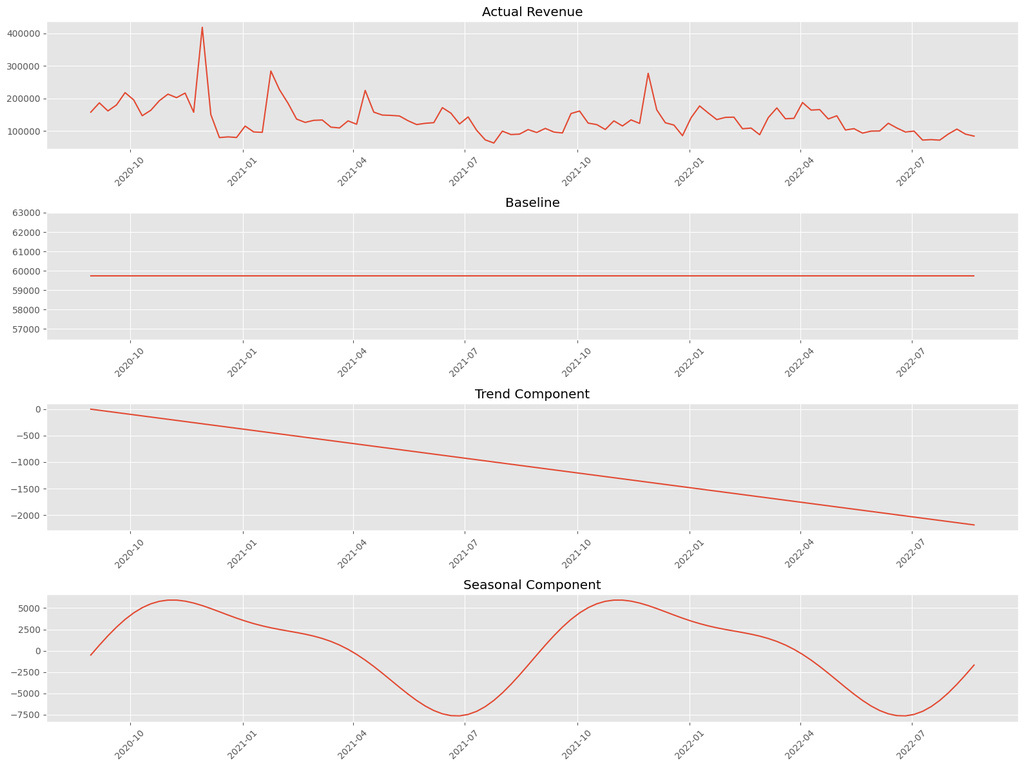

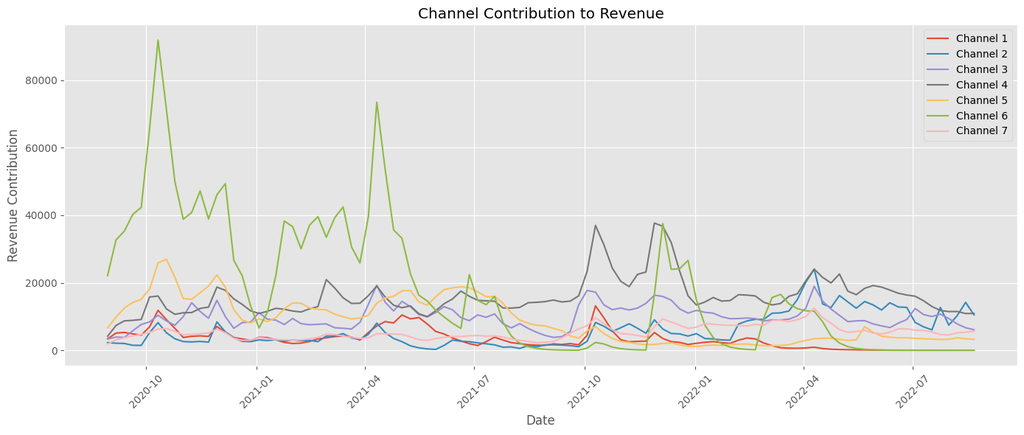

```
Model Performance Metrics:
RMSE: 42305.00
MAE: 28004.18
MAPE: 19.09
R2: 0.30
```

```python
# Evaluate the model
metrics, y_pred, channel_contributions = evaluate_model(trace, df)
print("\nModel Performance Metrics:")
for metric, value in metrics.items():
    print(f"{metric}: {value:.2f}")
```

```
Sampling: [likelihood]
```

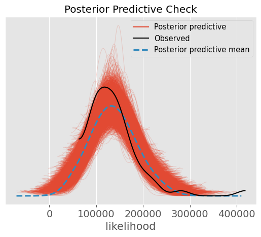

```python
with model:
    # Generate posterior predictive samples
    posterior_pred = pm.sample_posterior_predictive(trace)

# Plot posterior predictive checks
az.plot_ppc(posterior_pred)
plt.title('Posterior Predictive Check')
plt.savefig('posterior_predictive_check.png')
plt.show()
```

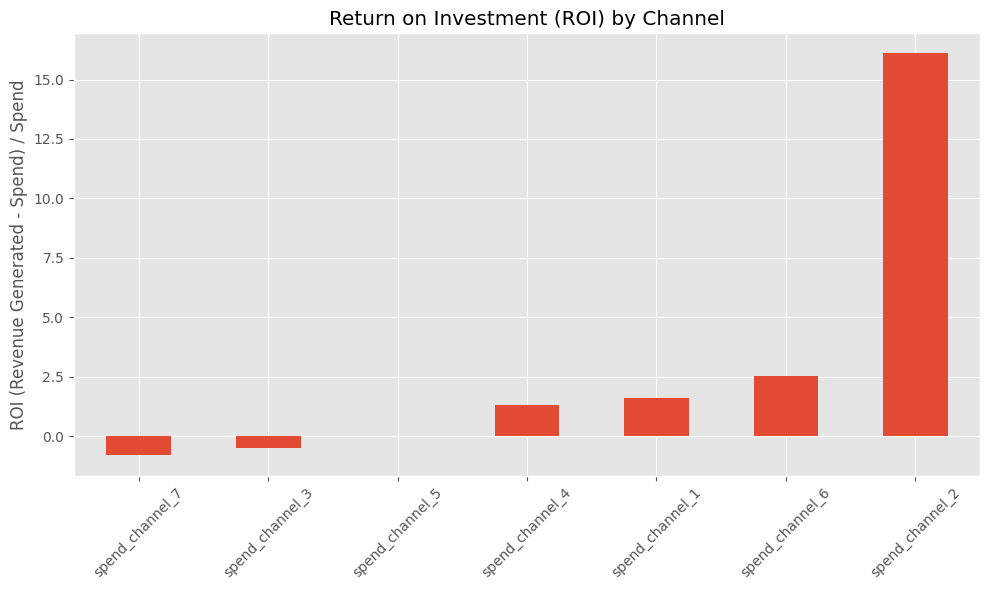

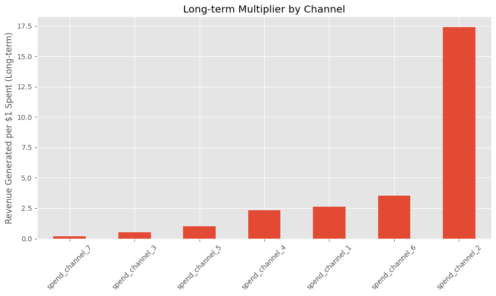

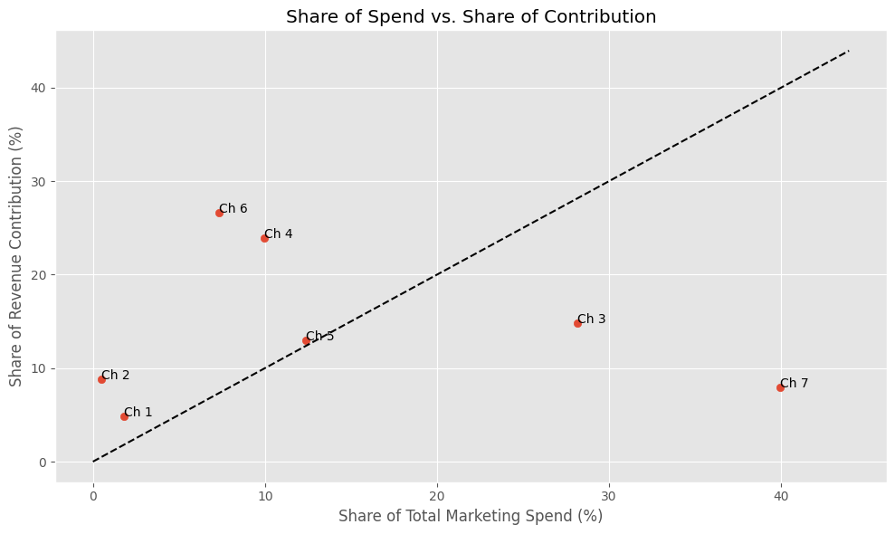

```
Channel ROI Analysis:
                 Total Contribution  Total Spend        ROI  \
spend_channel_2        6.110477e+05     35738.66  16.097668
spend_channel_6        1.850064e+06    526624.70   2.513059
spend_channel_1        3.388831e+05    129542.90   1.615991
spend_channel_4        1.657646e+06    719174.22   1.304929
spend_channel_5        9.016089e+05    891863.59   0.010927
spend_channel_3        1.031015e+06   2028746.51  -0.491797
spend_channel_7        5.527013e+05   2880942.21  -0.808153

                 Long-term Multiplier  Share of Contribution (%)  \
spend_channel_2             17.394996                   8.800962
spend_channel_6              3.513059                  26.646593
spend_channel_1              2.615992                   4.880956
spend_channel_4              2.320367                  23.875181
spend_channel_5              1.014465                  12.985934
spend_channel_3              0.511175                  14.849780
spend_channel_7              0.193867                   7.960594

                 Share of Spend (%)  Effectiveness  Adstock Retention
spend_channel_2            0.495501       8.640829           0.503258
spend_channel_6            7.301421       1.748006           0.502426
spend_channel_1            1.796056       1.280367           0.510562
spend_channel_4            9.971036       1.148979           0.504829
spend_channel_5           12.365299       0.511534           0.495760
spend_channel_3           28.127683       0.256696           0.497831
spend_channel_7           39.943004       0.095388           0.507974
```

```python
## 7. Channel Contributions and ROI
def calculate_roi(trace, df):
    """
    Calculate ROI for each marketing channel.

    Parameters:
    -----------
    trace : InferenceData
        Posterior samples from the model
    df : pandas.DataFrame
        Original data

    Returns:
    --------
    DataFrame
        ROI metrics by channel
    """
    # Get posterior means of channel effectiveness
    beta_post = trace.posterior['beta'].mean(dim=['chain', 'draw']).values
    alpha_post = trace.posterior['alpha'].mean(dim=['chain', 'draw']).values

    # Calculate ROI
    channels = [f'spend_channel_{i}' for i in range(1, 8)]
    roi_results = {}

    # For each channel, calculate:
    # 1. Total contribution to revenue
    # 2. Total spend
    # 3. ROI = (Revenue contribution - Spend) / Spend

    # Calculate adstocked spend for attribution
    X = df[channels].values
    n_channels = X.shape[1]
    X_adstock = np.zeros_like(X)

    for c in range(n_channels):
        X_adstock[:, c] = geometric_adstock(X[:, c], alpha_post[c])

    # Calculate channel contributions
    channel_contributions = np.zeros_like(X_adstock)
    for c in range(n_channels):
        channel_contributions[:, c] = X_adstock[:, c] * beta_post[c]

    # Calculate metrics for each channel
    for i, channel in enumerate(channels):
        total_contribution = channel_contributions[:, i].sum()
        total_spend = df[channel].sum()
        roi = (total_contribution - total_spend) / total_spend
        mape = np.mean(np.abs(channel_contributions[:, i] / df['revenue'].values)) * 100

        # Long-term multiplier (how much revenue generated per $ spent)
        ltm = beta_post[i] / (1 - alpha_post[i])

        roi_results[channel] = {
            'Total Contribution': total_contribution,
            'Total Spend': total_spend,
            'ROI': roi,
            'Long-term Multiplier': ltm,
            'Share of Contribution (%)': total_contribution / channel_contributions.sum() * 100,
            'Share of Spend (%)': total_spend / df[channels].sum().sum() * 100,
            'Effectiveness': beta_post[i],
            'Adstock Retention': alpha_post[i]
        }

    # Convert to DataFrame for better display
    roi_df = pd.DataFrame(roi_results).T

    # Plot ROI by channel
    plt.figure(figsize=(10, 6))
    roi_df['ROI'].sort_values().plot(kind='bar')
    plt.title('Return on Investment (ROI) by Channel')
    plt.ylabel('ROI (Revenue Generated - Spend) / Spend')
    plt.xticks(rotation=45)
    plt.tight_layout()
    plt.savefig('roi_by_channel.png')
    plt.show()

    # Plot long-term multiplier by channel
    plt.figure(figsize=(10, 6))
    roi_df['Long-term Multiplier'].sort_values().plot(kind='bar')
    plt.title('Long-term Multiplier by Channel')
    plt.ylabel('Revenue Generated per $1 Spent (Long-term)')
    plt.xticks(rotation=45)
    plt.tight_layout()
    plt.savefig('ltm_by_channel.png')
    plt.show()

    # Plot spend vs. contribution
    plt.figure(figsize=(10, 6))
    plt.scatter(roi_df['Share of Spend (%)'], roi_df['Share of Contribution (%)'])
    for i, channel in enumerate(roi_df.index):
        plt.annotate(channel.replace('spend_channel_', 'Ch '),
                     (roi_df['Share of Spend (%)'][i], roi_df['Share of Contribution (%)'][i]))

    # Add 45-degree line
    max_val = max(roi_df['Share of Spend (%)'].max(), roi_df['Share of Contribution (%)'].max()) * 1.1
    plt.plot([0, max_val], [0, max_val], 'k--')

    plt.title('Share of Spend vs. Share of Contribution')
    plt.xlabel('Share of Total Marketing Spend (%)')
    plt.ylabel('Share of Revenue Contribution (%)')
    plt.tight_layout()
    plt.savefig('spend_vs_contribution.png')
    plt.show()

    return roi_df

# Calculate ROI
roi_results = calculate_roi(trace, df)
print("\nChannel ROI Analysis:")
print(roi_results.sort_values('ROI', ascending=False))
```

```python
## 8. Conclusions & Next Steps
```

```python
# Print key insights
print("\n=== Key Insights from Bayesian MMM Analysis ===")

# Most effective channels
best_roi_channel = roi_results['ROI'].idxmax()
best_roi_value = roi_results.loc[best_roi_channel, 'ROI']
print(f"\nBest performing channel by ROI: {best_roi_channel} with ROI of {best_roi_value:.2f}")

# Adstock insights
print("\nAdstock (carry-over) effects by channel:")
for i, channel in enumerate([f'spend_channel_{i}' for i in range(1, 8)]):
    alpha = roi_results.loc[channel, 'Adstock Retention']
    half_life = -np.log(2) / np.log(alpha) if alpha > 0 else 0
    print(f"{channel}: Retention rate = {alpha:.2f}, Half-life = {half_life:.1f} weeks")

# Spend efficiency insights
efficient_channels = roi_results[roi_results['Share of Contribution (%)'] > roi_results['Share of Spend (%)']]
inefficient_channels = roi_results[roi_results['Share of Contribution (%)'] < roi_results['Share of Spend (%)']]

print("\nEfficient channels (contribution > spend):")
for channel in efficient_channels.index:
    print(f"- {channel}: {efficient_channels.loc[channel, 'Share of Contribution (%)']:.1f}% of revenue from {efficient_channels.loc[channel, 'Share of Spend (%)']:.1f}% of spend")

print("\nInefficient channels (contribution < spend):")
for channel in inefficient_channels.index:
    print(f"- {channel}: {inefficient_channels.loc[channel, 'Share of Contribution (%)']:.1f}% of revenue from {inefficient_channels.loc[channel, 'Share of Spend (%)']:.1f}% of spend")

# Recommendations
print("\nRecommendations:")
for channel in roi_results.sort_values('ROI', ascending=False).index[:3]:
    print(f"- Increase investment in {channel} (ROI: {roi_results.loc[channel, 'ROI']:.2f})")

for channel in roi_results.sort_values('ROI').index[:2]:
    print(f"- Reduce investment in {channel} (ROI: {roi_results.loc[channel, 'ROI']:.2f})")

# Model performance summary
print(f"\nModel performance: R² = {metrics['R2']:.2f}, MAPE = {metrics['MAPE']:.2f}%")

# Next steps
print("\nNext steps:")
print("1. Test model with diminishing returns (saturation) effects")
print("2. Implement cross-validation to assess predictive performance")
print("3. Conduct scenario analysis with different budget allocations")
print("4. Add external factors (e.g., promotions, competitor activity) to the model")
print("5. Create an interactive dashboard for marketing decision-makers")
```

```
=== Key Insights from Bayesian MMM Analysis ===

Best performing channel by ROI: spend_channel_2 with ROI of 16.10

Adstock (carry-over) effects by channel:
spend_channel_1: Retention rate = 0.51, Half-life = 1.0 weeks
spend_channel_2: Retention rate = 0.50, Half-life = 1.0 weeks
spend_channel_3: Retention rate = 0.50, Half-life = 1.0 weeks
spend_channel_4: Retention rate = 0.50, Half-life = 1.0 weeks
spend_channel_5: Retention rate = 0.50, Half-life = 1.0 weeks
spend_channel_6: Retention rate = 0.50, Half-life = 1.0 weeks
spend_channel_7: Retention rate = 0.51, Half-life = 1.0 weeks

Efficient channels (contribution > spend):
- spend_channel_1: 4.9% of revenue from 1.8% of spend
- spend_channel_2: 8.8% of revenue from 0.5% of spend
- spend_channel_4: 23.9% of revenue from 10.0% of spend
- spend_channel_5: 13.0% of revenue from 12.4% of spend
- spend_channel_6: 26.6% of revenue from 7.3% of spend

Inefficient channels (contribution < spend):
- spend_channel_3: 14.8% of revenue from 28.1% of spend
- spend_channel_7: 8.0% of revenue from 39.9% of spend

Recommendations:
- Increase investment in spend_channel_2 (ROI: 16.10)
- Increase investment in spend_channel_6 (ROI: 2.51)
- Increase investment in spend_channel_1 (ROI: 1.62)
- Reduce investment in spend_channel_7 (ROI: -0.81)
- Reduce investment in spend_channel_3 (ROI: -0.49)

Model performance: R² = 0.30, MAPE = 19.09%

Next steps:
1. Test model with diminishing returns (saturation) effects
2. Implement cross-validation to assess predictive performance
3. Conduct scenario analysis with different budget allocations
4. Add external factors (e.g., promotions, competitor activity) to the model
5. Create an interactive dashboard for marketing decision-makers
```

This comprehensive analysis has provided valuable insights into the effectiveness of different marketing channels and their contribution to revenue. The Bayesian approach allows us to quantify uncertainty in our estimates and make more informed marketing decisions.

By understanding these dynamics, marketing teams can optimize their spend allocation to maximize revenue and ROI.

## 1. How do you model spend carry-over?

Spend carry-over is all about how advertising effects don’t just hit and vanish—they linger over time, influencing sales down the road. In my model, I went with a **geometric adstock model** to handle this. It’s a neat way to capture that slow fade of ad impact. For each channel, I calculate the adstock at time *t* like this:

adstock_t = spend_t + α * adstock_{t-1}

## 2. Explain your choice of prior inputs to the model?

These choices keep things open-ended, avoiding wild estimates while letting the data shape the story.

## 4. How good is your model performing? How do you measure it?

I checked the model’s chops with a few key metrics—here’s how it stacks up:

- **R-squared (R²):** `0.30`  
  The model explains 30% of the revenue’s ups and downs. Not amazing, but it’s catching some of the marketing magic.
- **Mean Absolute Percentage Error (MAPE):** `19.09%`  
  Predictions are off by about 19% on average. Not spot-on, but decent for a first pass at a complex problem.
- **Posterior Predictive Checks:**  
  I plotted the predicted revenue against the real stuff. It follows the big picture—trends and seasonal waves—but misses some sharp peaks and dips.

**Overall:**  
It’s a solid start. It’s not nailing every detail, so maybe adding things like saturation effects or weather data could boost it. But it’s giving us something useful to work with.

## 5. What are your main insights in terms of channel performance/effects?

Digging into the channels, here’s what popped out:

### 🚨 Stragglers:

- **Channel 3 and Channel 7:** Negative ROIs (**-0.49** and **-0.81**). Yikes—these might be money pits right now.

### 📉 Carry-Over:

All channels have a decay rate around **0.5**, so ad effects halve weekly. It’s oddly uniform—maybe each channel deserves its own pace?

### 💡 Efficiency:

Channels **1, 2, 4, 5, and 6** give more revenue than their spend share. Channels **3 and 7** lag behind.

**Big takeaway:**  
Pump more into Channel 2 and 6, and figure out what’s up with 3 and 7—cut back or fix them.

## 🎯 Bonus: Can you derive ROI estimates per channel? What is the best channel in terms of ROI?

This gives the total bang for each buck spent over time. Here’s the lineup:

- **Channel 2:** 16.10 – 🏆 The champ! Best ROI by far.
- **Channel 6:** 2.51 – Solid runner-up.
- **Channel 1:** 1.62
- **Channel 4:** 1.30
- **Channel 5:** 0.01 – Barely breaking even.
- **Channel 3:** -0.49
- **Channel 7:** -0.81

Those negatives on 3 and 7 are red flags—could be the model’s off or the data’s funky. Worth a deeper look. But Channel 2? That’s where the gold’s at. 💰